# STATS 60 Rlab Session 5

Yuchen Wu

2020/7/22

# Recap of Session 4

- tidyr: gather and separate
- working directory

# `tidyr::gather()`

E.g. dataset of no. of cases for each country

```r
df
```

```
## # A tibble: 3 x 3
##   country     `1999` `2000`
##   <chr>        <dbl>  <dbl>
## 1 Afghanistan    745   2666
## 2 Brazil       37737  80488
## 3 China       212258 213766
```

# `tidyr::gather()`

**How to make a line plot of no. of cases by year for each country?**

```r
df
```

```
## # A tibble: 3 x 3
##   country     `1999` `2000`
##   <chr>        <dbl>  <dbl>
## 1 Afghanistan    745   2666
## 2 Brazil       37737  80488
## 3 China       212258 213766
```

Probably want something like

```r
ggplot(df) +
    geom_line(aes(x = year, y = cases, group = country))
```

# `tidyr::gather()`

**How to make a line plot of no. of cases by year for each country?**

**Problem:** Column names are values of the variable `year`.

```r
df
```

```
## # A tibble: 3 x 3
##   country     `1999` `2000`
##   <chr>        <dbl>  <dbl>
## 1 Afghanistan    745   2666
## 2 Brazil       37737  80488
## 3 China       212258 213766
```

# `tidyr::gather()`

**How to make a line plot of no. of cases by year for each country?**

**Solution:** Reshape dataset:

```r
df %>% gather(`1999`, `2000`, key = "year", value = "cases")
```

```
## # A tibble: 6 x 3
##   country     year   cases
##   <chr>       <chr>  <dbl>
## 1 Afghanistan 1999     745
## 2 Brazil      1999   37737
## 3 China       1999  212258
## 4 Afghanistan 2000    2666
## 5 Brazil      2000   80488
## 6 China       2000  213766
```

# `tidyr::separate()`

E.g. dataset of rate (cases / population) for each country

```r
df
```

```
## # A tibble: 6 x 3
##   country      year rate
##   <chr>       <dbl> <chr>
## 1 Afghanistan  1999 745/19987071
## 2 Afghanistan  2000 2666/20595360
## 3 Brazil       1999 37737/172006362
## 4 Brazil       2000 80488/174504898
## 5 China        1999 212258/1272915272
## 6 China        2000 213766/1280428583
```

# `tidyr::separate()`

**How to get cases and population into columns of their own?**

```r
df
```

```
## # A tibble: 6 x 3
##   country      year rate
##   <chr>       <dbl> <chr>
## 1 Afghanistan  1999 745/19987071
## 2 Afghanistan  2000 2666/20595360
## 3 Brazil       1999 37737/172006362
## 4 Brazil       2000 80488/174504898
## 5 China        1999 212258/1272915272
## 6 China        2000 213766/1280428583
```

# `tidyr::separate()`

**How to get cases and population into columns of their own?**

**Solution:** Use `tidyr`’s `separate()`

```r
df %>% separate(rate, into = c("cases", "population"), sep = "/")
```

```
## # A tibble: 6 x 4
##   country      year cases  population
##   <chr>       <dbl> <chr>  <chr>
## 1 Afghanistan  1999 745    19987071
## 2 Afghanistan  2000 2666   20595360
## 3 Brazil       1999 37737  172006362
## 4 Brazil       2000 80488  174504898
## 5 China        1999 212258 1272915272
## 6 China        2000 213766 1280428583
```

# Agenda for today

- Factors
- Random sampling with R

# Factors

- A concept unique to R
- Useful for working with categorical variables: variables that have a fixed and known set of possible values
- Both numeric and character variables can be made into factors

# Why use factor variables instead of character variables?

**Reason 1:** Character variables don’t protect you from typos

```r
x <- c("Dec", "Apr", "Jam", "Mar")
```

# Why use factor variables instead of character variables?

**Reason 1:** Character variables don’t protect you from typos

```r
x <- c("Dec", "Apr", "Jam", "Mar")
```

**Reason 2:** Character variables don’t sort in a useful way

```r
x <- c("Dec", "Apr", "Jan", "Mar")
sort(x)
```

```
## [1] "Apr" "Dec" "Jan" "Mar"
```

# Why use factor variables instead of character variables?

**Reason 1:** Character variables don’t protect you from typos

```r
x <- c("Dec", "Apr", "Jam", "Mar")
```

**Reason 2:** Character variables don’t sort in a useful way

```r
x <- c("Dec", "Apr", "Jan", "Mar")
sort(x)
```

```
## [1] "Apr" "Dec" "Jan" "Mar"
```

Factor variables can fix both of these easily.

# How to convert a character variable to a factor variable?

- Use `factor()` (in base R)
- Give the function the list of valid categories, or **levels**

```r
month_levels <- c(
  "Jan", "Feb", "Mar", "Apr", "May", "Jun",
  "Jul", "Aug", "Sep", "Oct", "Nov", "Dec"
)
x <- c("Dec", "Apr", "Jam", "Mar")
```

# How to convert a character variable to a factor variable?

- Use `factor()` (in base R)
- Give the function the list of valid categories, or **levels**

```r
y1 <- factor(x, levels = month_levels, ordered =TRUE)
y1
```

```
## [1] Dec  Apr  <NA> Mar
## 12 Levels: Jan < Feb < Mar < Apr < May < Jun < Jul < Aug < Sep < ... < Dec
```

# How to convert a character variable to a factor variable?

- Use `factor()` (in base R)
- Give the function the list of valid categories, or **levels**

```r
sort(y1)
```

```
## [1] Mar Apr Dec
## 12 Levels: Jan < Feb < Mar < Apr < May < Jun < Jul < Aug < Sep < ... < Dec
```

# Why use factor variables instead of numerical variables?

- Could change the content of factors easily by changing the “levels” or “labels”.

```r
data = c(1,2,2,3,1,2,3,3,1,2,3,3,1)
fdata = factor(data)
fdata
```

```
##  [1] 1 2 2 3 1 2 3 3 1 2 3 3 1
## Levels: 1 2 3
```

```r
rdata = factor(data,labels=c("I","II","III"))
rdata
```

```
##  [1] I   II  II  III I   II  III III I   II  III III I
## Levels: I II III
```

```r
levels(fdata) = c('I','II','III')
fdata
```

```
##  [1] I   II  II  III I   II  III III I   II  III III I
## Levels: I II III
```

# Generating random data

R contains many functions that allow you generate random data either from a vector of data that you specify (like Heads or Tails from a coin), or from an established probability distribution, like the Normal or Uniform distribution.

# sample()

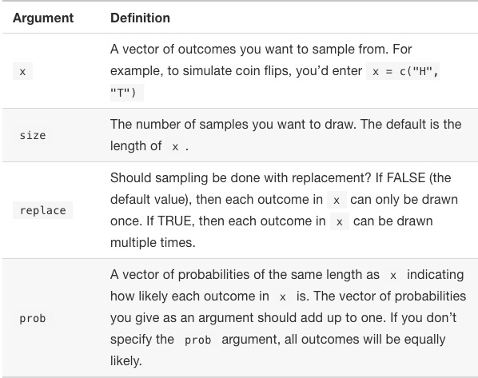

# sample()

```r
# From the integers 1:10, draw 5 numbers, without replacement
sample(x = 1:10, size  = 5)
```

```
## [1] 5 6 8 9 3
```

```r
# From the integers 1:10, draw 5 numbers, with replacement
sample(x = 1:10, size  = 5, replace = TRUE)
```

```
## [1] 1 1 2 7 1
```

# sample()

```r
sample(x = c("H", "T"), # The possible values of the coin
       size = 10,  # 10 flips
       replace = TRUE) # Sampling with replacement
```

```
##  [1] "T" "T" "H" "H" "T" "T" "H" "H" "H" "H"
```

```r
sample(x = c("H", "T"),
       prob = c(.8, .2), # Make the coin biased for Heads
       size = 10,
       replace = TRUE)
```

```
##  [1] "H" "H" "T" "H" "H" "T" "H" "H" "H" "H"
```

# Generate random data from specified probability distribution

```r
?Distributions
```

# Normal distribution

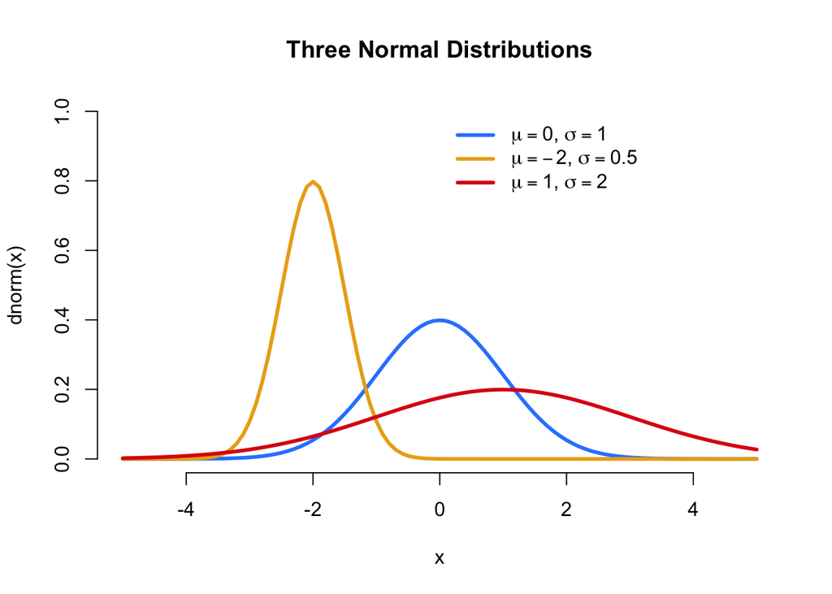

# Normal distribution

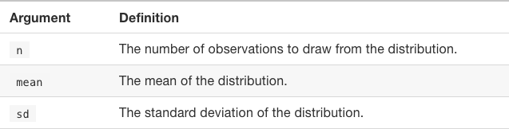

# Normal distribution

```r
 # 5 samples from a Normal dist with mean = 0, sd = 1
rnorm(n = 5, mean = 0, sd = 1)
```

```
## [1]  0.64967554  0.68991786  1.41764235 -0.35829427 -0.06418326
```

```r
# 3 samples from a Normal dist with mean = -10, sd = 15
rnorm(n = 3, mean = -10, sd = 15)
```

```
## [1] -32.119474 -42.201002   0.119997
```

Because the sampling is done randomly, you will get different values each time you run rnorm().

# Uniform Distribution

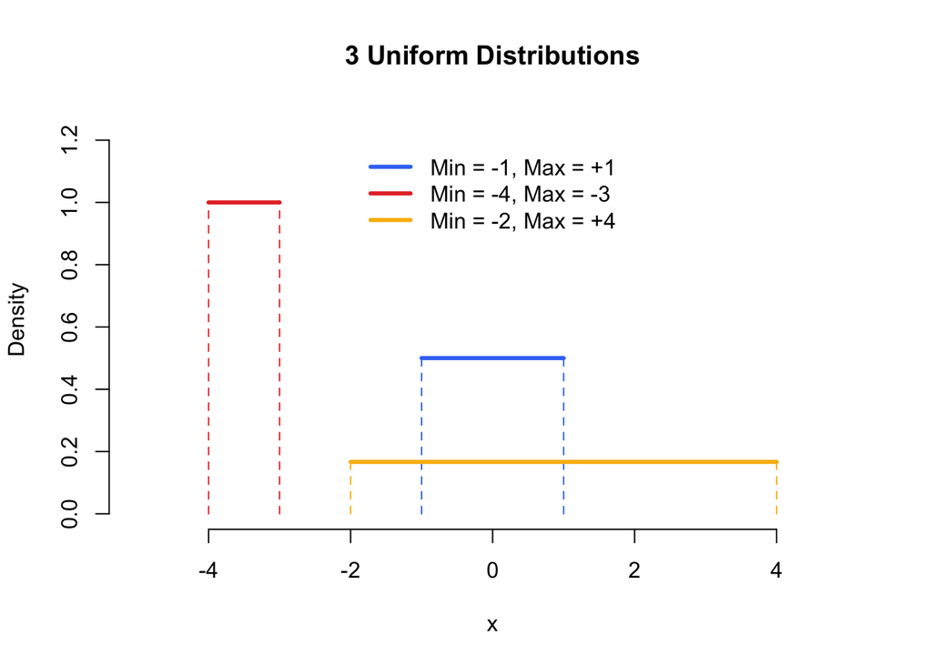

# Uniform distribution

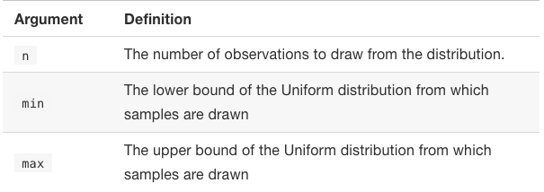

# Uniform distribution

```r
# 5 samples from Uniform dist with bounds at 0 and 1
runif(n = 5, min = 0, max = 1)
```

```
## [1] 0.43948645 0.00909191 0.55663140 0.53614440 0.54634026
```

```r
# 10 samples from Uniform dist with bounds at -100 and +100
runif(n = 10, min = -100, max = 100)
```

```
##  [1]  -9.921079  64.775792  42.996560  42.510502 -83.201566 -59.280297
##  [7]   7.649564  69.167467  18.237490  98.842050
```

# Random samples will always change

Every time you draw a sample from a probability distribution, you will(likely) get a different result.

```r
# Draw a sample of size 5 from a normal distribution with mean 100 and sd 10
rnorm(n = 5, mean = 100, sd = 10)
```

```
## [1]  95.81486 104.28819 103.88127  93.95388 102.88365
```

```r
# Do it again!
rnorm(n = 5, mean = 100, sd = 10)
```

```
## [1] 106.10249  94.83656  89.86620 105.02997 101.63315
```

# Use set.seed() to control random samples

```r
set.seed(100)
rnorm(3, mean = 0, sd = 1)
```

```
## [1] -0.50219235  0.13153117 -0.07891709
```

```r
# The result will always be -0.5022, 0.1315, -0.0789
set.seed(100)
rnorm(3, mean = 0, sd = 1)
```

```
## [1] -0.50219235  0.13153117 -0.07891709
```